# ExCM_Analysis_Output

Anja Kranjc Horvat

11/26/2020

Libraries `igraph` and `qgraph` are standard libraries for network analysis in R.

```r
library(igraph)
library(qgraph)
library('visNetwork')
```

The concept map has been written in a .dot file, transformed to adjacency matrix via RStudio, and manually updated to present weighted edges. The weights will be manipulated in the programme below, therefore their values are arbitrary.

```r
#read the weighted adjacency file and take only columns 2:188,
#as the first column is only row names, which are not needed
dat <- read.csv("neki2.csv")
aMat <- dat[1:187,2:188]
DaMat <- dat[1:187,2:188]

#change the data into a matrix
DaMat <- as.matrix(DaMat)
DaMat <- as.directed(graph.adjacency(DaMat))
```

Now we manipulate the matrices to put them in the right format for the first analysis with all examples included.

```r
#set all weights to same for the first centralities
aMat[aMat=="20"]="1"
aMat <- as.matrix(aMat)
aMat <- as.directed(graph.adjacency(aMat))

#check if the graph is connected
is_connected(aMat)
```

```
## [1] TRUE
```

Now we calculate the centralities for the data with included examples. `centrality_auto` calculates several centrality measures at the same time, including *betweenness*, *closeness*, and *degree* centrality. The latter (and several others) we identified as not relevant for our study, therefore we will only focus on *betweenness* and *centrality*. Additionally, we include a third measure of centrality, namely the *PageRank*. That one needs to be calculated separately.

```r
#creates a table with the Betweenness and Closeness for all concepts
cFull <- centrality_auto(aMat)
cFull <- cFull$node.centrality

#calculate PageRank for all concepts
PRFull <- page.rank(aMat, directed=TRUE)
PRFull <- PRFull$vector
PRFull <- data.frame(matrix(unlist(PRFull), nrow=187, byrow=T))
```

That was simple!

… now comes the hard part. First, we prepare the data for the second analysis without included examples. In the original file, examples have the weight of **1**, while main concepts have the weight of **20** (arbitrary numbers). Now, we will set examples to **0** and main concepts to **1** (the latter is not really necessary, we only set it to 1 for faster calculations). The rows and columns with examples now have a sum of **0** in the adjacency matrix (they are not connected), therefore we can remove them by identifying the zero sums.

```r
#prepare for a new table with no examples
aMat2 <- dat[1:187, 2:188]
aMat2[aMat2==1] = 0
aMat2[aMat2==20] = 1
aMat2 <- as.data.frame(aMat2)

#delete the zero columns and rows (examples)
aMat2 <- aMat2[which(colSums(aMat2)!=0), which(colSums(aMat2)!=0)]
aMat2 <- aMat2[which(colSums(aMat2)!=0), which(colSums(aMat2)!=0)]
bMat2 <- aMat2
aMat2 <- as.matrix(aMat2)
aMat2 <- as.directed(graph.adjacency(aMat2))
```

Now we can analyse the new matrix with the same procedure as before. First, we identify *betweenness* and *centrality*, and then we move on to *PageRank*.

```r
#create a list with the Betweenness and Closeness
cMain <- centrality_auto(aMat2)
cMain <- cMain$node.centrality

#calculate PageRank
PRMain <- page.rank(aMat2,directed=TRUE)
PRMain <- PRMain$vector
PRMain <- data.frame(matrix(unlist(PRMain), nrow=87, byrow=T))
```

```r
#create a table for betweenness, closeness, and PageRank
BIGcMain <- data.frame(nrow=187,ncol=4)
BIGcMain[1:187,1] <- row.names(cFull)
BIGcMain[1:187, 2:4] = 0
for(i in 1:187){
  for(j in 1:87){
    if(rownames(cMain)[j]==BIGcMain[i,1]){
    BIGcMain[i,2]=cMain[j,1]
    BIGcMain[i,3]=cMain[j,2]
    BIGcMain[i,4]=PRMain[j,1]
    break
    }
  }
}
```

Almost done! We now put all results in one big table, always keeping the full analysis with examples in the first and the analysis without examples in the second column.

```r
#overview of all three centralities
cenTable <- cbind(BFull=cFull$Betweenness,BMain=BIGcMain$ncol,
                  CFull=cFull$Closeness,CMain=BIGcMain$V3,
                  PrFull=PRFull[,1],PrMain=BIGcMain$V4)
cenTable[1:10,]
```

```
##           BFull     BMain        CFull       CMain      PrFull      PrMain
##  [1,] 1024.8333 492.50000 0.0011534025 0.002881844 0.012079311 0.020579077
##  [2,]  302.0833  57.33333 0.0012690355 0.003048780 0.004820737 0.007596528
##  [3,]  187.0000  91.00000 0.0011086475 0.002724796 0.006185620 0.011534742
##  [4,]  186.0000   0.00000 0.0000000000 0.000000000 0.006204132 0.009943542
##  [5,]  545.5000 227.00000 0.0009699321 0.002341920 0.006510096 0.011044775
##  [6,]  310.6667 152.83333 0.0009523810 0.002325581 0.011321571 0.018357593
##  [7,]  252.1667 180.16667 0.0012484395 0.003134796 0.004820737 0.007596528
##  [8,]  343.3667 157.11667 0.0013175231 0.003205128 0.005640262 0.008887937
##  [9,] 1228.4000 511.23333 0.0011933174 0.002824859 0.008362256 0.014823400
## [10,]    0.0000   0.00000 0.0000000000 0.000000000 0.003866167 0.000000000
```

As these numbers tell us nothing, we need to do additional analysis. First, let’s make a plot. For that, we need to manipulate the data around a bit. Here, I could probably make it neater, but it serves the purpose this way, and I know why what is where :)

```r
#ranking table for betweenness with examples
BPlotTable <- data.frame(nrow=187, ncol=2)
BPlotTable[1:187,2] <- cenTable[1:187,1]
BPlotTable <- BPlotTable[order(-BPlotTable$ncol),]
for(i in 1:187){
  BPlotTable[i,1] = i
  a<-as.numeric(rownames(BPlotTable)[i])
  BPlotTable[i,3] <- dat[a,1]
}

#ranking table for betweenness without examples
BPlotTable2 <- BPlotTable
BPlotTable2[1:187,2] <- BIGcMain[1:187,2]
BPlotTable2[1:187,3] <- BIGcMain[1:187,1]
BPlotTable2 <- BPlotTable2[order(-BPlotTable2$ncol),]
for(i in 1:187){
  BPlotTable2[i,1] = i
}

#ranking table for closeness with examples
CPlotTable <- data.frame(nrow=187,ncol=2)
CPlotTable[1:187,2] <- cenTable[1:187,3]
CPlotTable <- CPlotTable[order(-CPlotTable$ncol),]
for(i in 1:187){
  CPlotTable[i,1] = i
  a<-as.numeric(rownames(CPlotTable)[i])
  CPlotTable[i,3] <- dat[a,1]
}

#ranking table for closeness without examples
CPlotTable2 <- CPlotTable
CPlotTable2[1:187,2] <- BIGcMain[1:187,3]
CPlotTable2[1:187,3] <- BIGcMain[1:187,1]
CPlotTable2 <- CPlotTable2[order(-CPlotTable2$ncol),]
for(i in 1:187){
  CPlotTable2[i,1] = i
}

#ranking table for PageRank with examples
PRPlotTable <- data.frame(nrow=187,ncol=2)
PRPlotTable[1:187,2] <- cenTable[1:187,5]
PRPlotTable <- PRPlotTable[order(-PRPlotTable$ncol),]
for(i in 1:187){
  PRPlotTable[i,1] = i
  a<-as.numeric(rownames(PRPlotTable)[i])
  PRPlotTable[i,3] <- dat[a,1]
}

#ranking table for PageRank without examples
PRPlotTable2 <- CPlotTable
PRPlotTable2[1:187,2] <- BIGcMain[1:187,4]
PRPlotTable2[1:187,3] <- BIGcMain[1:187,1]
PRPlotTable2 <- PRPlotTable2[order(-PRPlotTable2$ncol),]
for(i in 1:187){
  PRPlotTable2[i,1] = i
}
```

Based on these tables, we can finally look at the top 10 for all included centralities.

```r
rank <- data.frame()
for(i in 1:187){
  rank[i,1] = i
}
Top10 <- data.frame(Rank=rank,
                    Betweenness.With.Examples = BPlotTable[1:187,3], Betweenness.No.Examples = BPlotTable2[1:187,3],
                    Closeness.With.Examples = CPlotTable[1:187,3],Closeness.No.Examples = CPlotTable2[1:187,3],
                    PageRank.With.Examples = PRPlotTable[1:187,3], PageRank.No.Examples = PRPlotTable2[1:187,3])
Top10
```

```
##      V1                   Betweenness.With.Examples
## 1     1                    Fundamental interactions
## 2     2                                  Collisions
## 3     3                        Elementary particles
## 4     4                Theoretical particle physics
## 5     5               Experimental particle physics
## 6     6                          Particle detectors
## 7     7                       Particle accelerators
## 8     8          Standard Model of particle physics
## 9     9                                        CERN
## 10   10                                    Fermions
## 11   11                           Conservation laws
## 12   12                                    Analysis
## 13   13                                 Predictions
## 14   14                                        Data
```

[output cut: 1113 more lines]

Based on those tables, we build plots to see if there are any kinks in the data. Here, it is important to note, that all centrality measures here have been ordered separately. Therefore, the #1 in betweenness with examples is not necessarily #1 in betweenness without examples etc.

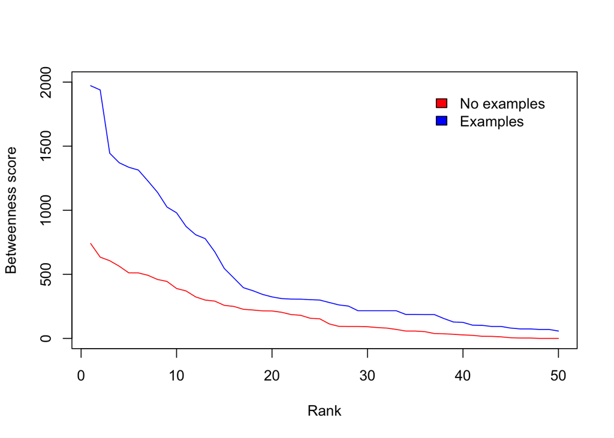

```r
#plotting betweenness
plot(BPlotTable[1:50,1], BPlotTable[1:50,2],
     type="l", col="blue", xlab="Rank", ylab="Betweenness score",ylim=c(0,2000))
lines(BPlotTable2[1:50,1], BPlotTable2[1:50,2],
      type="l", col="red")
legend("topright",inset=.05, c("No examples","Examples"),
       fill=c("red","blue"), horiz=FALSE, box.lty = 0)
```

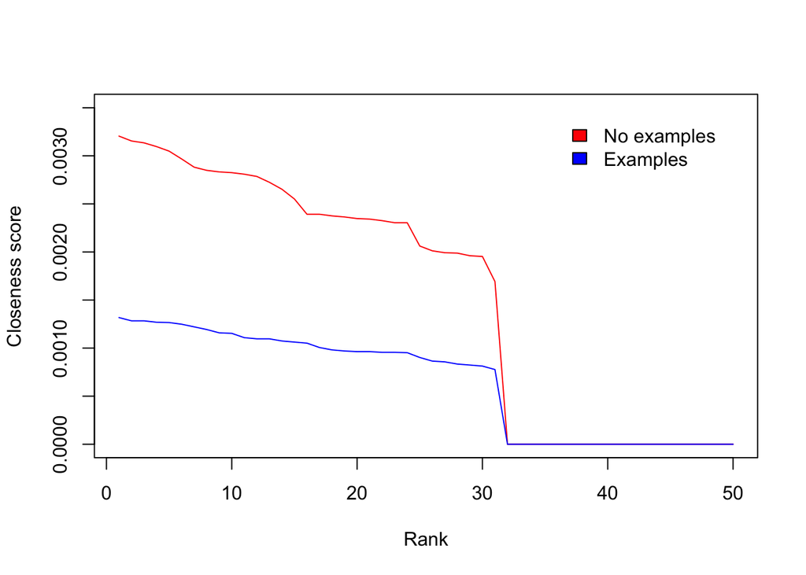

```r
#plotting closeness
plot(CPlotTable2[1:50,1], CPlotTable2[1:50,2],
     type="l", col="red", xlab="Rank", ylab="Closeness score",ylim=c(0,0.0035))
lines(CPlotTable[1:50,1], CPlotTable[1:50,2],
      type="l", col="blue")
legend("topright",inset=.05, c("No examples","Examples"),
       fill=c("red","blue"), horiz=FALSE, box.lty = 0)
```

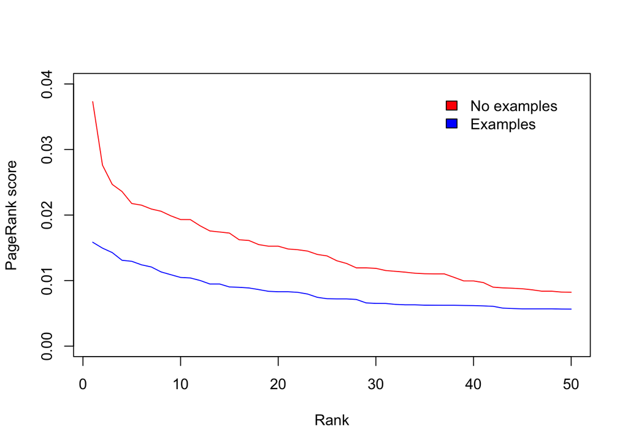

```r
#plotting PageRank
plot(PRPlotTable2[1:50,1], PRPlotTable2[1:50,2],
     type="l", col="red", xlab="Rank", ylab="PageRank score",ylim=c(0,0.040))
lines(PRPlotTable[1:50,1], PRPlotTable[1:50,2],
      type="l", col="blue")
legend("topright",inset=.05, c("No examples","Examples"),
       fill=c("red","blue"), horiz=FALSE, box.lty = 0)
```

As we can see, betweenness has a slight kink in the very beginning, but then is has quite a nice curve going on. Closeness, however, only has bigger data until about the 30th concept, regardless of whether or not we include examples.

The analysis with or without examples seem to be converging after a while, and we wanted to know, whether or not the results are correlated. This we do with the help of the Spearman test, to which we add the `exact = FALSE` to allow analysis even in case of ties (which do happen). To see at which point the differences in ranking become insignificant, we plot the p-values of the correlation test in relation to the number of included concepts. E.g., if the number of included concepts it 5, this means that we included the top 5 ranked concepts in the correlation analysis.

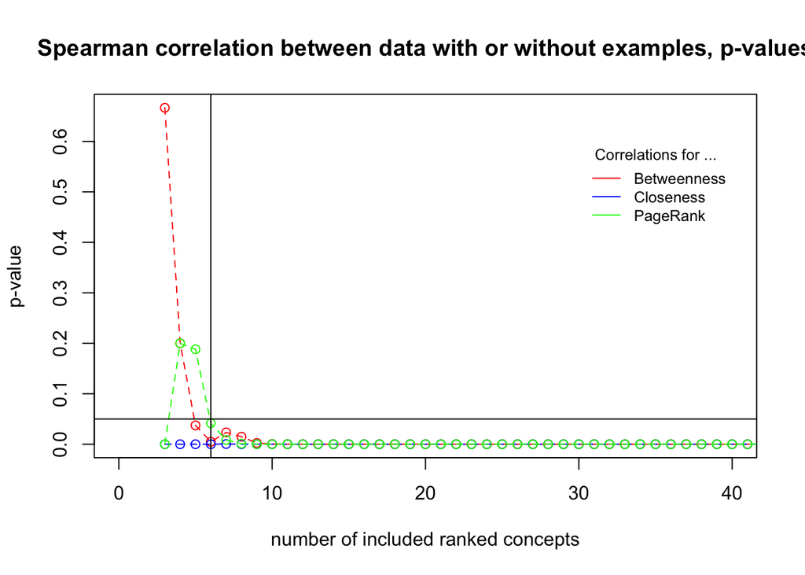

```r
cor.tab<-data.frame()

for(i in 3:187){
  b<-cor.test(~ BFull + BMain, data = cenTable[1:i,1:6], method="spearman",exact=FALSE)
  c<-cor.test(~ CFull + CMain, data = cenTable[1:i,1:6], method="spearman",exact=FALSE)
  d<-cor.test(~ PrFull + PrMain, data = cenTable[1:i,1:6], method="spearman",exact=FALSE)
  cor.tab[i-2,1]<-i
  cor.tab[i-2,2]<-b$p.value
  cor.tab[i-2,3]<-c$p.value
  cor.tab[i-2,4]<-d$p.value
}

plot(x=cor.tab[1:40,1],y=cor.tab[1:40,2],type="o", lty=2,col = "red", xlab="number of included ranked concepts", ylab="p-value", main="Spearman correlation between data with or without examples, p-values",xlim=c(0,40))
lines(x=cor.tab[1:40,1],y=cor.tab[1:40,3],type="o", lty=2,col = "blue")
lines(x=cor.tab[1:40,1],y=cor.tab[1:40,4],type="o", lty=2,col = "green")
abline(h=0.05, v=6)
legend(30, 0.6, legend=c("Betweenness", "Closeness", "PageRank"),
       col=c("red", "blue", "green"), lty=1, cex=0.8, title="Correlations for ...",box.lty = 0)
```

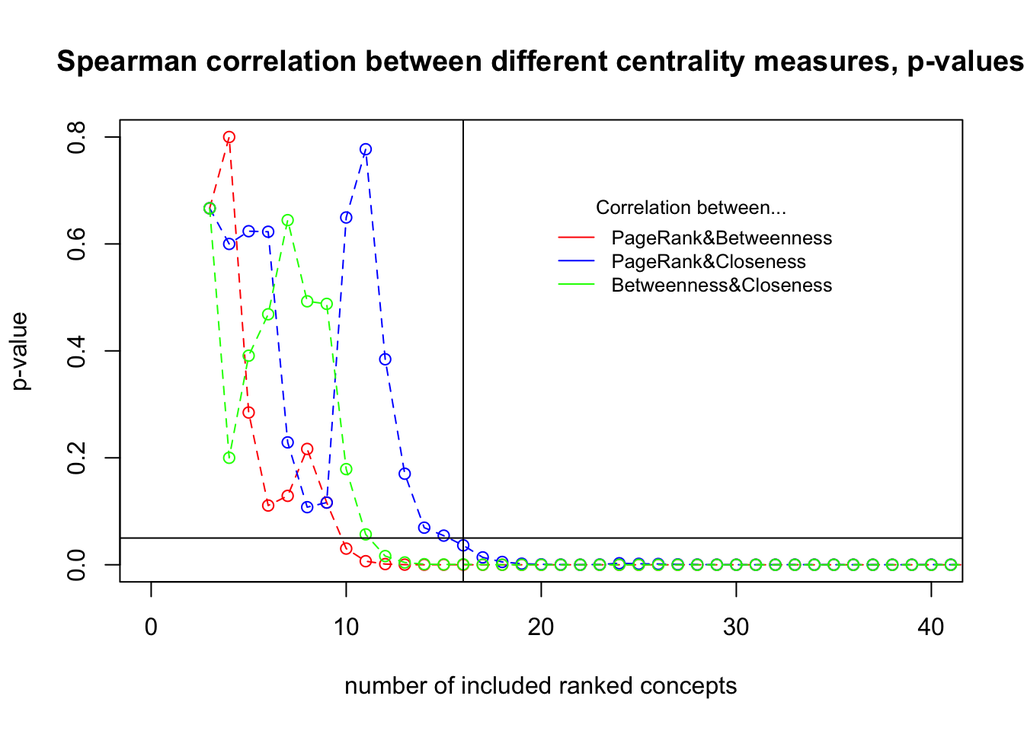

```r
cor.table<-data.frame()

for(i in 3:187){
  b<-cor.test(~ PrFull + BFull, data = cenTable[1:i,1:6], method="spearman",exact=FALSE)
  c<-cor.test(~ PrFull + CFull, data = cenTable[1:i,1:6], method="spearman",exact=FALSE)
  d<-cor.test(~ BFull + CFull, data = cenTable[1:i,1:6], method="spearman",exact=FALSE)
  cor.table[i-2,1]<-i
  cor.table[i-2,2]<-b$p.value
  cor.table[i-2,3]<-c$p.value
  cor.table[i-2,4]<-d$p.value
}

plot(x=cor.table[1:40,1],y=cor.table[1:40,2],type="o", lty=2,col = "red", xlab="number of included ranked concepts", ylab="p-value", main="Spearman correlation between different centrality measures, p-values",xlim=c(0,40))
lines(x=cor.table[1:40,1],y=cor.table[1:40,3],type = "o",lty=2,col = "blue")
lines(x=cor.table[1:40,1],y=cor.table[1:40,4],type = "o",lty=2,col = "green")
abline(h=0.05, v=16)
legend(20, 0.7, legend=c("PageRank&Betweenness", "PageRank&Closeness", "Betweenness&Closeness"),
       col=c("red", "blue", "green"), lty=1, cex=0.8, title="Correlation between...",box.lty = 0)
```

What we can see from this plot is that after 16 included concepts, the centrality measures stop being significantly different between each other. /n

To finish this, you can finally make your first graph, **hooray**! Here we used the data for *betweenness* of concepts with examples as a function for the size of the nodes.

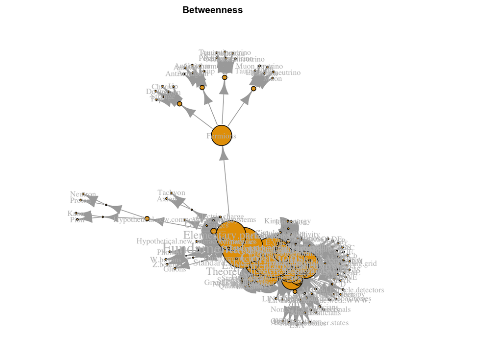

```r
#draw the concept map
Betweenness<-betweenness(DaMat)
layout(matrix(1:40, 100, 100, byrow = TRUE))
par(mar=c(0, 2, 2, 0))
plot(DaMat, vertex.label.cex=2*(Betweenness)/(max(Betweenness)),
     vertex.label.color="grey", main="Betweenness",
     vertex.size=(30*Betweenness)/max(Betweenness))
```

Now, we use the data for *betweenness* of concepts without examples as a function for the size of the nodes.

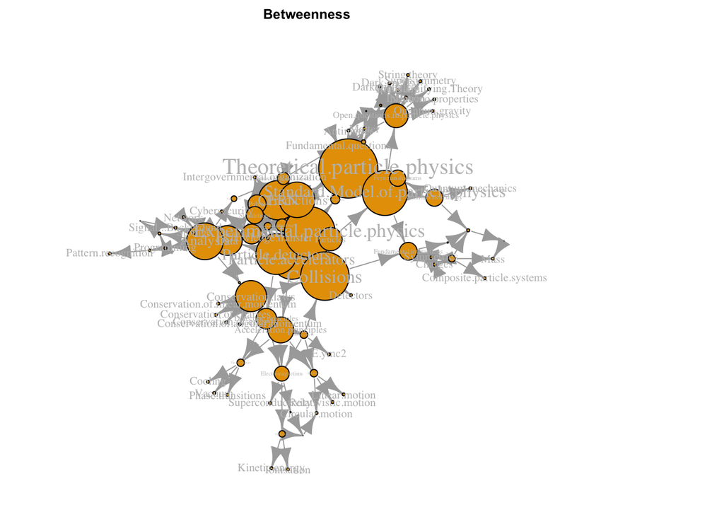

```r
#draw the concept map
palf <- colorRampPalette(c("gray80", "dark red"))
Betweenness<-betweenness(aMat2)
layout(matrix(1:40, 100, 100, byrow = TRUE))
par(mar=c(0, 2, 2, 0))
plot(aMat2, vertex.label.cex=2*(Betweenness)/(max(Betweenness)),
     vertex.label.color="grey", main="Betweenness",
     vertex.size=(30*Betweenness)/max(Betweenness))
```

But do you want to see something really, really, REALLY cool? Here it is. The final monster. The interactive representation of the concept map with color-coded levels and node sizes that reflect the betweenness. Truly fancy stuff.

```r
test.visn <- toVisNetworkData(aMat)
test.visn.nodes<-test.visn$nodes
test.visn.edges<-test.visn$edges
edges <- read.csv("edges_labels.csv")

#exported the nodes, added levels manually from the concept map
nodes <- read.csv("nodes_Level.csv")
nodes$size <- ((30*cFull$Betweenness/max(cFull$Betweenness))+5)
edges$arrows <- "to"
edges$title<-edges$name
nodes$color.background <- c("#d53e4f","#f46d43","#fdae61","#fee08b","#e6f598","#abdda4","#66c2a5","#3288bd")[nodes$Level]
nodes$color.highlight.background <- c("#9e0142","#d53e4f","#f46d43","#fdae61","#fee08b","#ffffbf","#e6f598","#abdda4")[nodes$Level]
visnet<-visNetwork(nodes, edges)
visOptions(visnet, highlightNearest = TRUE, selectedBy = "Level")
```

[interactive chart not shown]

I might be biased, but this is pretty cool (however useless :).